# Feature Selection Analysis

# Analysis Objective

We intend to analyze data from ADNI to identify small molecules for drug re-purposing for Alzheimer’s Disease treatment and prevention.  
The data we intend to mine will be patient data that can be linked to small molecules:

- medical/Drug History
- Biological Data
- Patient Demographics, and Predispositions

We hope to discover any information that will help link small molecules and drugs to risk reduction or improvement of Alzheimer’s disease. These insights will facilitate further testing of small molecules using Autodock Vina and in vitro / vivo studies during this research term and those in future studies.

# Data

## About

The data table used in this analysis contains information from the following tables.  
**ADNIMERGE:** Baseline diagnoses and basic patient information have been extracted from ADNIMERGE. ADNIMERGE is a table provided by ADNI containing key information from many other merged data tables and serves as a good starting point for data analysis.

- Includes demographics, neuropsychological testing scores, MRI and PET summaries, CSF measures.
- Also includes both a baseline diagnosis and diagnosis at each visit.

**RECCMEDS:** Drug information has been extracted for all study phases from RECCMEDS (Concurrent Medications Log [ADNI1,GO,2,3]).  
**INITHEALTH:** Condition information has been extracted for ADNI3 from INITHEALTH (initial health screening, ADNI3).  
**MEDHIST:** Condition information has been extracted for ADNI1/GO/2 from MEDHIST (Medical History [ADNI1,GO,2]).  
**RECMHIST:** Key recent condition information has been extracted for ADNI1/GO/2 from RECMHIST (Recent Medical History Details Log [ADNI1,GO,2]).  
**LABDATA:** Bio sample information has been extracted for ADNI1/GO/2 from LABDATA (Laboratory Data [ADNI1,GO, 2])  
**URMC_LABDATA:** Bio sample information has been extracted for ADNI13 from URMC_LABDATA (Laboratory Data [3])

## Prep

The data in used in this analysis is pre assembled and cleaned.  
**See:** *Analysis-Data-Prep.Rmd*  
for data assembly.  
**See:** *Full-Table-Cleaning.Rmd*  
for data cleaning.

### Required Libraries

```r
library(rstatix)
library(maditr)
library(ordinalNet)
library(caret)
library(leaps)
library(nnet)
library(MASS)
library(glmnet)
library(survival)
library(tidyverse)
library(lubridate)
library(Rdimtools)
library(janitor)
library(survival)
library(survminer)
```

### Reading Data

```r
data_cleaned <- read_csv("/Users/liamf/OneDrive/Documents/ADNI Work R/Data/Created Tables/main_data_cleaned.csv", col_types = cols(
  .default = col_double(),
  VISCODE2 = col_character(),
  COLPROT = col_character(),
  DX_bl = col_character(),
  AGE = col_double(),
  PTGENDER = col_character(),
  PTETHCAT = col_character(),
  PTRACCAT = col_character(),
  PTMARRY = col_character(),
  study_enrolled = col_character(),
  DX_bl_recoded = col_character(),
  st_enrol_dx_bl = col_character()
  )
)
```

### Analysing NA Values

```r
na_amounts <- data_cleaned %>%
  summarise_all(
    function(col) sum(is.na(col))
  ) %>%
  rowid_to_column()

na_amounts <- dcast(melt(na_amounts, id.vars = "rowid"), variable ~ rowid) %>%
  rename(n_na = "1") %>%
  arrange(desc(n_na))

write_csv(na_amounts, "/Users/liamf/OneDrive/Documents/ADNI Work R/Data/Created Tables/na_amounts.csv")
```

# Analysis

Use the feature selection / variable screening techniques to find associations between aspects of patient data and their AD assessments. The AD assessment that will be used to categorize patients is their diagnosis at base line. This diagnoses is reliable as it is the result of blood / urine / CSF tests, PET and MRI scans, and neuropsychological examinations.  
Each patient variable will be compared and screened for its connection to the patients baseline diagnoses via by multiple analyses depending on the data type. These variable screening analyses will include:

- Penalized Ordinal Regression
- Regularized Cox Proportional Hazards Regression
- ChiSq
- t-test / Anova

Each technique will tell us if there is a useful connection between the independent and dependent variable. We can then use this information to assess if we want to investigate the insight further.  
The methodlogy for this analysis has been inspired from the following article:  
https://towardsdatascience.com/the-5-feature-selection-algorithms-every-data-scientist-need-to-know-3a6b566efd2

## Penalized Ordinal Regression

### Data Prep

#### ADNI1GO2

```r
POR_data_ADNI1GO2 <- data_cleaned %>%
  select(5, 7, 11, 12, 17, 19:124, 165: 198, 200:218, "HMT13", "HMT102", "HMT4", "HMT2", "RCT29", "BAT126", "HMT100", "HMT10", "HMT11", "HMT12", "HMT15", "HMT16", "HMT17", "HMT18", "HMT19", "HMT3", "HMT40", "HMT7", "HMT8", "HMT9", "RCT5", "RCT14", "RCT1", "RCT13", "RCT4", "RCT11", "RCT19", "RCT20", "RCT9", "RCT12", "RCT1407", "RCT183", "RCT3", "RCT392", "RCT6", "RCT8") %>%
  drop_na() %>%
  select_if(function(col)
    if (is.character(col)) {TRUE}
    else if (sum(col) > 29) {TRUE}
    else FALSE
  )

x_ADNI1GO2 <- POR_data_ADNI1GO2 %>%
  select(-DX_bl_recoded) %>%
  as.matrix

y_ADNI1GO2 <- as.factor(
  mutate(POR_data_ADNI1GO2[5], DX_bl_recoded =
    case_when(
      DX_bl_recoded == "CN" ~ 1,
      DX_bl_recoded == "MCI" ~ 2,
      DX_bl_recoded == "AD" ~ 3,
    )
  )[[1]]
)
```

#### ADNI3

```r
# Bio Data Excluded for Being To Missing
POR_data_ADNI3 <- data_cleaned %>%
  select(5, 7, 11, 12, 17, 19:164) %>%
  drop_na() %>%
  select_if(function(col)
    if (is.character(col)) {TRUE}
    else if (sum(col) > 29) {TRUE}
    else FALSE
  )

x_ADNI3 <- POR_data_ADNI3 %>%
  select(-DX_bl_recoded) %>%
  as.matrix

y_ADNI3 <- as.factor(
  mutate(POR_data_ADNI3[5], DX_bl_recoded =
    case_when(
      DX_bl_recoded == "CN" ~ 1,
      DX_bl_recoded == "MCI" ~ 2,
      DX_bl_recoded == "AD" ~ 3,
    )
  )[[1]]
)
```

### Model Fitting

#### ADNI1GO2

```r
fit1_ADNI1GO2 <- ordinalNet(x_ADNI1GO2,
                   y_ADNI1GO2,
                   family = "cumulative",
                   link = "logit",
                   standardize = TRUE,
                   parallelTerms=TRUE, nonparallelTerms=FALSE)
```

#### ADNI3

```r
fit1_ADNI3 <- ordinalNet(x_ADNI3,
                   y_ADNI3,
                   family = "cumulative",
                   link = "logit",
                   standardize = TRUE,
                   parallelTerms=TRUE, nonparallelTerms=FALSE)
```

### Results

#### ADNI1GO2

```r
specify_decimal <- function(x, k) trimws(format(round(x, k), nsmall=k))

as.data.frame(
  coef(fit1_ADNI1GO2, matrix=TRUE)
) %>%
  select(1)  %>%
  rename(logit = 'logit(P[Y<=1])') %>%
  filter(logit != 0) %>%
  rownames_to_column() %>%
  mutate(coef_sign =
    case_when(
      logit < 0 ~ "-",
      logit > 0 ~ "+"
    )
  ) %>%
  mutate(logit = abs(logit)) %>%
  arrange(desc(logit)) %>%
  mutate(logit = specify_decimal(logit, 3))
```

```
##                      rowname  logit coef_sign
## 1                (Intercept) 24.012         -
## 2              CMMED_aricept  1.854         -
## 3            CMMED_donepezil  1.662         -
## 4              CMMED_namenda  1.040         -
## 5            CMMED_metformin  0.911         -
## 6               CMMED_diovan  0.877         +
## 7               CMMED_exelon  0.840         -
## 8                    MMSE_bl  0.838         +
## 9          CMMED_pravastatin  0.753         -
## 10        CMMED_coenzyme q10  0.358         +
## 11    MHDESC_cholecystectomy  0.344         -
## 12  MHDESC_seasonalallergies  0.321         -
## 13             CMMED_crestor  0.313         -
## 14               CMMED_zetia  0.299         +
```

[output cut: 48 more lines]

#### ADNI3

```r
as.data.frame(
  coef(fit1_ADNI3, matrix=TRUE)
) %>%
  select(1)  %>%
  rename(logit = 'logit(P[Y<=1])') %>%
  filter(logit != 0) %>%
  rownames_to_column() %>%
  mutate(coef_sign =
    case_when(
      logit < 0 ~ "-",
      logit > 0 ~ "+"
    )
  ) %>%
  mutate(logit = abs(logit)) %>%
  arrange(desc(logit)) %>%
  mutate(logit = specify_decimal(logit, 3))
```

```
##                        rowname  logit coef_sign
## 1                  (Intercept) 15.474         -
## 2                 IHSYMPTOM_19  1.414         -
## 3              CMMED_donepezil  1.339         -
## 4                      MMSE_bl  0.651         +
## 5                  IHSYMPTOM_5  0.612         -
## 6                        APOE4  0.556         -
## 7              CMMED_magnesium  0.420         -
## 8  IHDESC_hypercholesterolemia  0.389         +
## 9      IHDESC_high cholesterol  0.357         -
## 10          CMMED_multivitamin  0.355         +
## 11           IHDESC_osteopenia  0.346         +
## 12                 IHSYMPTOM_2  0.338         -
## 13       IHDESC_osteoarthritis  0.287         +
## 14             CMMED_metformin  0.283         +
## 15         IHDESC_osteoporosis  0.245         +
## 16            CMMED_lisinopril  0.240         -
## 17                IHSYMPTOM_13  0.180         +
## 18                IHSYMPTOM_14  0.135         -
## 19                IHSYMPTOM_18  0.131         +
## 20        IHDESC_tonsillectomy  0.118         +
## 21                 IHSYMPTOM_1  0.112         -
## 22            CMMED_amlodipine  0.078         -
## 23         IHDESC_hysterectomy  0.046         +
## 24                         AGE  0.029         -
## 25           CMMED_vitamin b12  0.027         -
## 26          CMMED_atorvastatin  0.021         +
```

Here a sign of + means less AD and a sign of - means the opposite.

## Regularized Cox Proportional Hazards Regression

### Data Prep

```r
subjects <- data_cleaned %>%
  filter(COLPROT != 'ADNI3') %>%
  filter(DX_bl_recoded == 'MCI') %>%
  select(1, 5, 7, 11, 12, 17, 19:124, 165: 198, 200:218, "HMT13", "HMT102", "HMT4", "HMT2", "RCT29", "BAT126", "HMT100", "HMT10", "HMT11", "HMT12", "HMT15", "HMT16", "HMT17", "HMT18", "HMT19", "HMT3", "HMT40", "HMT7", "HMT8", "HMT9", "RCT5", "RCT14", "RCT1", "RCT13", "RCT4", "RCT11", "RCT19", "RCT20", "RCT9", "RCT12", "RCT1407", "RCT183", "RCT3", "RCT392", "RCT6", "RCT8") %>%
  drop_na() %>%
  select_if(function(col)
    if (is.character(col)) {TRUE}
    else if (sum(col) > 29) {TRUE}
    else FALSE
  )

follow_ups <- read_csv('/Users/liamf/OneDrive/Documents/ADNI/Data/ADNIMERGE.csv') %>%
  filter(RID %in% subjects[[1]]) %>%
  filter(VISCODE != "bl") %>%
  drop_na(DX) %>%
  rename(VISCODE2 = VISCODE) %>%
  mutate(EXAMDATE = str_replace_all(EXAMDATE, "-", "/")) %>%
  mutate(EXAMDATE = ymd(EXAMDATE)) %>%
  mutate(phase_VIS_EXAM_DX = paste(COLPROT, VISCODE2, EXAMDATE, DX, sep = " ")) %>%
  group_by(RID) %>%
  arrange(-desc(EXAMDATE)) %>%
  mutate(visits = paste0(phase_VIS_EXAM_DX, collapse = ", ")) %>%
  group_by(RID, visits) %>%
  summarise() %>%
  mutate(visits = strsplit(visits, ", "))

surv_data <- data.frame(RID = double(), mci_to_dimentia = integer(), date = character(), stringsAsFactors=FALSE)
vector = follow_ups[[2]]

for (i in 1:nrow(follow_ups)) {
  vec = vector[[i]]
  dimentia_coverted <- 0
  final_date <- strsplit(vec[length(vec)], " ")[[1]][3]

  for (elem in vec) {
    visit <- strsplit(elem, " ")[[1]]

    if (visit[4] == "Dementia") {
      dimentia_coverted <- 1
      final_date <- visit[3]
    }
  }
  surv_data[nrow(surv_data) + 1,] = c(follow_ups[[1]][i], dimentia_coverted, final_date)
}

surv_data <- surv_data %>%
  mutate(date = ymd(date)) %>%
  left_join(read_csv('/Users/liamf/OneDrive/Documents/ADNI/Data/ADNIMERGE.csv') %>%
              filter(VISCODE == "bl") %>%
              mutate(RID = as.character(RID)) %>%
              select(RID, EXAMDATE),
            by = c("RID")) %>%
  mutate(t_dif = as.integer(difftime(date, EXAMDATE))) %>%
  mutate(RID = as.double(RID)) %>%
  filter(RID != 987) %>%
  filter(RID != 5066) %>%
  arrange(-desc(RID)) %>%
  select(RID, mci_to_dimentia, t_dif) %>%
  rename(time = t_dif) %>%
  mutate(time = as.numeric(time)) %>%
  rename(status = mci_to_dimentia) %>%
  mutate(status = as.numeric(status))

subjects <- subjects %>%
  filter(RID %in% surv_data[[1]]) %>%
  arrange(-desc(RID)) %>%
  select(-RID, -DX_bl_recoded)
```

The result here is a table *surv_data* which has status (developed Dementia or not) and the time is took to develop it. The other table is the patient information at their initial base line assessment which is the same data used for Penalized Ordinal Regression. An important note here as well is that only patients starting in ADNI1 / GO / 2 were included though they were followed into ADNI3.

### Model Fitting

```r
x <- as.matrix(subjects)
y = as.matrix(surv_data %>% select(-RID))

cvfit <- cv.glmnet(x, y, family = "cox", type.measure = "C")
```

### Results

```r
cvfit$lambda.min
```

```
## [1] 0.04937738
```

```r
cvfit$lambda.1se
```

```
## [1] 0.1140681
```

```r
coef(cvfit)
```

```
## 109 x 1 sparse Matrix of class "dgCMatrix"
##                                           1
## AGE                            .
## PTEDUCAT                       .
## APOE4                          0.0788177075
## MMSE_bl                       -0.0866888410
## CMMED_aricept                  0.1918883727
## CMMED_asa                      .
## CMMED_aspirin                  .
## CMMED_atenolol                 .
## CMMED_calcium                  .
## CMMED_centrum silver           .
## CMMED_daily multivitamin       .
## CMMED_fish oil                 .
## CMMED_flomax                   .
## CMMED_folic acid               .
## CMMED_fosamax                  .
## CMMED_glucosamine              .
## CMMED_glucosamine chondroitin  .
## CMMED_hydrochlorothiazide      .
## CMMED_ibuprofen                .
## CMMED_levothyroxine            .
## CMMED_lipitor                  .
## CMMED_lisinopril               .
## CMMED_metformin                .
## CMMED_metoprolol               .
## CMMED_multivitamin             .
## CMMED_multivitamins            .
## CMMED_mvi                      .
## CMMED_namenda                  .
## CMMED_nexium                   .
## CMMED_omeprazole               .
## CMMED_prilosec                 .
## CMMED_simvastatin              .
## CMMED_synthroid                .
## CMMED_tylenol                  .
## CMMED_vitamin b12              .
## CMMED_vitamin c                .
## CMMED_vitamin d                .
## CMMED_vitamin d3               .
```

[output cut: 56 more lines]

```
## RCT14                          .
## RCT1                           .
## RCT13                          .
## RCT4                           .
## RCT11                          .
## RCT19                          .
## RCT20                          .
## RCT9                           .
## RCT12                          .
## RCT1407                        .
## RCT183                         .
## RCT3                           .
## RCT392                         .
## RCT6                           .
## RCT8                           .
```

Here a coefficient of - means less AD and + means more.

### Assumption Checking

```r
res.cox <- coxph(Surv(time, status) ~ APOE4 + MMSE_bl + CMMED_aricept + HMT16, data = surv_data %>% add_column(subjects))
test.ph <- cox.zph(res.cox)
test.ph
```

```
##                 chisq df     p
## APOE4          5.6829  1 0.017
## MMSE_bl        0.0652  1 0.798
## CMMED_aricept  0.3942  1 0.530
## HMT16          4.4098  1 0.036
## GLOBAL        10.3613  4 0.035
```

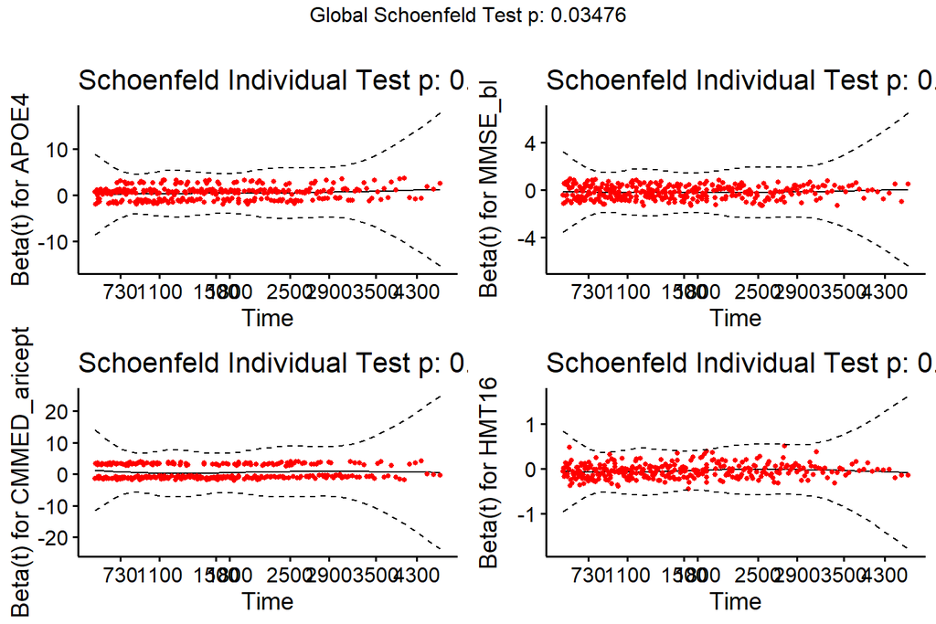

```r
ggcoxzph(test.ph)
```

## ChiSquared

### ADNI1GO2

```r
Chi_data_ADNI1GO2 <- data.frame(x = character(), y = character(), p = double(), statistic = double())

for (x in append(c(3), 6:117)) {
  test <- chisq.test(POR_data_ADNI1GO2[[x]], POR_data_ADNI1GO2[[5]])
  Chi_data_ADNI1GO2[nrow(Chi_data_ADNI1GO2) + 1,] <- c(names(POR_data_ADNI1GO2)[[x]], names(POR_data_ADNI1GO2)[[5]], test$p.value[[1]], test$statistic[[1]])
}

Chi_data_ADNI1GO2 <- Chi_data_ADNI1GO2 %>%
  mutate(p = as.numeric(p)) %>%
  arrange(-desc(p)) %>%
  filter(p <= 0.05) %>%
  mutate(x = str_remove_all(x, " "))
Chi_data_ADNI1GO2
```

```
##                      x             y            p        statistic
## 1        CMMED_aricept DX_bl_recoded 9.828663e-73 331.606817714552
## 2        CMMED_namenda DX_bl_recoded 1.771861e-69 316.612682490855
## 3                APOE4 DX_bl_recoded 1.123594e-26  127.84779084088
## 4              MHPSYCH DX_bl_recoded 7.294965e-09 37.4721628353097
## 5      CMMED_donepezil DX_bl_recoded 8.209084e-09 37.2360488764606
## 6        CMMED_lexapro DX_bl_recoded 4.696576e-05 19.9321836237666
## 7         CMMED_exelon DX_bl_recoded 4.990580e-05 19.8107466725746
## 8    MHDESC_sleepapnea DX_bl_recoded 6.285542e-04 14.7441766182288
## 9         CMMED_zoloft DX_bl_recoded 8.583722e-04  14.120945515002
## 10   CMMED_glucosamine DX_bl_recoded 2.998957e-03 11.6189812697326
## 11             MH3HEAD DX_bl_recoded 1.079487e-02 9.05736802598813
## 12       CMMED_fishoil DX_bl_recoded 1.119917e-02 8.98383128024991
## 13            MH8MUSCL DX_bl_recoded 1.362565e-02  8.5916024235349
## 14     CMMED_magnesium DX_bl_recoded 2.328511e-02 7.51988255485239
## 15            MH13ALLE DX_bl_recoded 2.359476e-02  7.4934614784732
## 16     MHDESC_insomnia DX_bl_recoded 2.552082e-02 7.33652164053366
## 17 MHDESC_osteoporosis DX_bl_recoded 2.698885e-02 7.22466257176883
## 18            MH10GAST DX_bl_recoded 2.922546e-02 7.06542993556702
## 19            MH2NEURL DX_bl_recoded 4.023151e-02 6.42620971794368
```

No direction of association only significance.

### ADNI3

```r
Chi_data_ADNI3 <- data.frame(x = character(), y = character(), p = double(), statistic = double())

for (i in append(append(c(3), 6:43), 45:60)) {
  test <- chisq.test(POR_data_ADNI3[[i]], POR_data_ADNI3[[5]])
  Chi_data_ADNI3[nrow(Chi_data_ADNI3) + 1,] <- c(names(POR_data_ADNI3)[[i]], names(POR_data_ADNI3)[[5]], test$p.value[[1]], test$statistic[[1]])
}

Chi_data_ADNI3 <- Chi_data_ADNI3%>%
  mutate(p = as.numeric(p)) %>%
  arrange(-desc(p)) %>%
  filter(p <= 0.05) %>%
  mutate(x = str_remove_all(x, " "))
Chi_data_ADNI3
```

```
##                       x             y            p        statistic
## 1       CMMED_donepezil DX_bl_recoded 6.556997e-19 83.7371680117388
## 2          IHSYMPTOM_19 DX_bl_recoded 1.966886e-15 67.7246498380103
## 3                 APOE4 DX_bl_recoded 4.564068e-07 35.0373206170761
## 4           IHSYMPTOM_5 DX_bl_recoded 8.681310e-04 14.0983358871259
## 5           IHSYMPTOM_2 DX_bl_recoded 1.479082e-02 8.42749663590148
## 6        IHDESC_anxiety DX_bl_recoded 2.085483e-02 7.74033912784599
## 7   IHDESC_hypertension DX_bl_recoded 2.655442e-02 7.25711793492306
## 8 IHDESC_hyperlipidemia DX_bl_recoded 3.832657e-02 6.52322388803285
## 9           IHSYMPTOM_4 DX_bl_recoded 4.748541e-02 6.09466548110311
```

No direction of association only significance.

### Checking for Age as Confounding

```r
assump_data <- POR_data_ADNI1GO2
colnames(assump_data) <- gsub(" ", "", colnames(assump_data))

for (x in Chi_data_ADNI1GO2[[1]]) {
  frm <- formula(paste("AGE~", x))
  model <- lm(frm, data = assump_data)
  print(summary(model)$coefficients)
  print(assump_data %>%
    group_by((!!as.name(x))) %>%
    summarise(avg = mean(AGE)))
}
```

```
##                 Estimate Std. Error    t value  Pr(>|t|)
## (Intercept)   73.7899377  0.2137945 345.144190 0.0000000
## CMMED_aricept  0.5604733  0.4316697   1.298384 0.1943567
## # A tibble: 2 x 2
##   CMMED_aricept   avg
##           <dbl> <dbl>
## 1             0  73.8
## 2             1  74.4
##                 Estimate Std. Error    t value  Pr(>|t|)
## (Intercept)   73.8200775  0.1994435 370.130238 0.0000000
## CMMED_namenda  0.8066902  0.5467500   1.475428 0.1403094
## # A tibble: 2 x 2
##   CMMED_namenda   avg
##           <dbl> <dbl>
## 1             0  73.8
## 2             1  74.6
##              Estimate Std. Error    t value     Pr(>|t|)
## (Intercept) 74.801997  0.2431288 307.664125 0.000000e+00
## APOE4       -1.507962  0.2740686  -5.502131 4.412485e-08
## # A tibble: 3 x 2
##   APOE4   avg
##   <dbl> <dbl>
## 1     0  74.7
## 2     1  73.6
## 3     2  71.2
##              Estimate Std. Error    t value     Pr(>|t|)
## (Intercept) 74.496945  0.2273510 327.673687 0.000000e+00
## MHPSYCH     -1.674811  0.3898729  -4.295786 1.853724e-05
## # A tibble: 2 x 2
##   MHPSYCH   avg
##     <dbl> <dbl>
## 1       0  74.5
## 2       1  72.8
##                  Estimate Std. Error    t value  Pr(>|t|)
## (Intercept)     73.977415  0.1888389 391.748832 0.0000000
## CMMED_donepezil -1.518231  1.0406265  -1.458959 0.1447878
## # A tibble: 2 x 2
##   CMMED_donepezil   avg
##             <dbl> <dbl>
## 1               0  74.0
```

[output cut: 98 more lines]

```
## (Intercept) 73.457805  0.2496762 294.212243 0.000000000
## MH10GAST     1.046087  0.3726408   2.807227 0.005062272
## # A tibble: 2 x 2
##   MH10GAST   avg
##      <dbl> <dbl>
## 1        0  73.5
## 2        1  74.5
##               Estimate Std. Error     t value  Pr(>|t|)
## (Intercept) 74.0131629  0.2205589 335.5709211 0.0000000
## MH2NEURL    -0.2953388  0.4093400  -0.7214999 0.4707155
## # A tibble: 2 x 2
##   MH2NEURL   avg
##      <dbl> <dbl>
## 1        0  74.0
## 2        1  73.7
```

```r
assump_data2 <- POR_data_ADNI3
colnames(assump_data2) <- gsub(" ", "", colnames(assump_data2))

for (x in Chi_data_ADNI3[[1]]) {
  frm <- formula(paste("AGE~", x))
  model <- lm(frm, data = assump_data2)
  print(summary(model)$coefficients)
  print(assump_data2 %>%
    group_by((!!as.name(x))) %>%
    summarise(avg = mean(AGE)))
}
```

```
##                  Estimate Std. Error    t value  Pr(>|t|)
## (Intercept)     71.268794  0.3447584 206.720988 0.0000000
## CMMED_donepezil  1.386761  1.1118124   1.247298 0.2129148
## # A tibble: 2 x 2
##   CMMED_donepezil   avg
##             <dbl> <dbl>
## 1               0  71.3
## 2               1  72.7
##              Estimate Std. Error    t value  Pr(>|t|)
## (Intercept)  71.25841  0.3476534 204.969681 0.0000000
## IHSYMPTOM_19  1.29351  1.0429603   1.240229 0.2155148
## # A tibble: 2 x 2
##   IHSYMPTOM_19   avg
##          <dbl> <dbl>
## 1            0  71.3
## 2            1  72.6
##              Estimate Std. Error    t value  Pr(>|t|)
## (Intercept) 72.028129  0.4140962 173.940586 0.0000000
## APOE4       -1.246657  0.5079769  -2.454161 0.0144862
## # A tibble: 3 x 2
##   APOE4   avg
##   <dbl> <dbl>
## 1     0  71.9
## 2     1  71.1
## 3     2  68.9
##               Estimate Std. Error     t value  Pr(>|t|)
## (Intercept) 71.3617318  0.3753568 190.1170641 0.0000000
## IHSYMPTOM_5  0.1719045  0.7742316   0.2220324 0.8243859
## # A tibble: 2 x 2
##   IHSYMPTOM_5   avg
##         <dbl> <dbl>
## 1           0  71.4
## 2           1  71.5
##              Estimate Std. Error    t value  Pr(>|t|)
## (Intercept) 71.020712  0.4029060 176.271152 0.0000000
## IHSYMPTOM_2  1.122684  0.6912389   1.624163 0.1050173
## # A tibble: 2 x 2
##   IHSYMPTOM_2   avg
##         <dbl> <dbl>
## 1           0  71.0
```

[output cut: 18 more lines]

```
## (Intercept)           71.022443  0.3769102 188.433321 0.0000000
## IHDESC_hyperlipidemia  1.531867  0.7570627   2.023435 0.0435986
## # A tibble: 2 x 2
##   IHDESC_hyperlipidemia   avg
##                   <dbl> <dbl>
## 1                     0  71.0
## 2                     1  72.6
##             Estimate Std. Error    t value     Pr(>|t|)
## (Intercept) 68.71645  0.5558335 123.627758 0.000000e+00
## IHSYMPTOM_4  3.97754  0.6764319   5.880178 7.824311e-09
## # A tibble: 2 x 2
##   IHSYMPTOM_4   avg
##         <dbl> <dbl>
## 1           0  68.7
## 2           1  72.7
```

No direction of association only significance.

## Anova

### ADNI1GO2

```r
ano_data_ADNI1GO2 <- data.frame(x = character(), y = character(), anova_f_statistic = double(), p_CN_t_test = double(), p_MCI_t_test = double(), CN_coef = double(), MCI_coef = double())
names_anova <- c("AGE", "PTEDUCAT", "MMSE_bl", "HMT13", "HMT102", "HMT4", "HMT2", "RCT29", "BAT126", "HMT100", "HMT10", "HMT11", "HMT12", "HMT15", "HMT16", "HMT17", "HMT18", "HMT19", "HMT3", "HMT40", "HMT7", "HMT8", "HMT9", "RCT5", "RCT14", "RCT1", "RCT13", "RCT4", "RCT11", "RCT19", "RCT20", "RCT9", "RCT12", "RCT1407", "RCT183", "RCT3", "RCT392", "RCT6", "RCT8")

for (x in names_anova) {
  frm <- formula(paste(x, "~DX_bl_recoded"))
  model <- lm(frm, data = POR_data_ADNI1GO2)
  ano_data_ADNI1GO2[nrow(ano_data_ADNI1GO2) + 1,] <- c(x,
                                     "DX_bl_recoded",
                                     summary(model)$fstatistic[[1]],
                                     summary(model)$coefficients[[2, 4]],
                                     summary(model)$coefficients[[3, 4]],
                                     summary(model)$coefficients[[2, 1]],
                                     summary(model)$coefficients[[3, 1]])
}

ano_data_ADNI1GO2 <- ano_data_ADNI1GO2 %>%
  mutate(p_CN_t_test = as.numeric(p_CN_t_test)) %>%
  arrange(-desc(p_CN_t_test)) %>%
  filter(p_CN_t_test <= 0.05)
ano_data_ADNI1GO2
```

```
##           x             y anova_f_statistic   p_CN_t_test          p_MCI_t_test
## 1   MMSE_bl DX_bl_recoded  1067.17232344695 1.458201e-278 2.48902431596629e-219
## 2  PTEDUCAT DX_bl_recoded  17.1874768188344  6.854473e-09  1.76749304937826e-05
## 3     HMT15 DX_bl_recoded  12.9104881409866  4.267320e-07   0.00128994846927311
## 4     HMT16 DX_bl_recoded  9.34410248996084  2.022290e-05    0.0199994403477409
## 5      HMT8 DX_bl_recoded  8.20368602282085  5.616282e-05   0.00413365710174058
## 6      RCT4 DX_bl_recoded  6.26423110606254  1.432921e-03   0.00119004865839685
## 7      RCT8 DX_bl_recoded  4.15292981050501  5.033176e-03     0.019939813514266
## 8     HMT18 DX_bl_recoded  3.24138179383952  1.119945e-02    0.0713170502667484
## 9    RCT392 DX_bl_recoded  3.06310159095441  1.485332e-02     0.199938704007164
## 10     HMT7 DX_bl_recoded  2.79871460037116  1.850657e-02    0.0904216982753784
## 11    HMT17 DX_bl_recoded  3.65466327982225  2.751792e-02   0.00869988375054912
## 12    RCT12 DX_bl_recoded   2.4056462351919  3.285909e-02    0.0754374558645909
## 13    RCT29 DX_bl_recoded  2.07074691938863  4.216566e-02     0.163955906656111
##                CN_coef             MCI_coef
## 1     5.95368421052636     4.45774398636687
## 2     1.28986842105264    0.847742020056359
## 3    -3.24381578947368    -1.83162089532671
## 4     2.54695614035087     1.23381355006443
## 5   -0.397714035087717   -0.251501955386595
## 6     2.09381578947368     1.89368814314738
## 7    0.298999999999998    0.220597758405975
## 8    0.377495614035084    0.238619213038818
## 9  -0.0439780701754393  -0.0205680452688383
## 10  -0.299562280701752   -0.191462716567255
## 11   0.302846491228066    0.320763365449734
## 12 -0.0734210526315782  -0.0543986366913543
## 13 -0.0095175438596495 -0.00579712044744483
```

### ADNI3

```r
ano_data_ADNI3 <- data.frame(x = character(), y = character(), anova_f_statistic = double(), p_CN_t_test = double(), p_MCI_t_test = double(), CN_coef = double(), MCI_coef = double())

names_anova2 <- c("NEU%", "LYM%", "MON%", "EOS%", "BAS%", "NEUA", "LYMA", "MONA", "EOSA", "BASA", "TB", "PLT", "CK", "X338", "K", "CL", "CO2", "UN", "CRE2", "GLU", "CA2", "PO4", "URIC", "TP", "ALB", "ALK", "CHOL", "TRIG", "RBC", "HGB", "HCT", "UPH")

for (x in names_anova2) {
  ano_data <- data_cleaned %>%
    select(DX_bl_recoded, x) %>%
    clean_names() %>%
    drop_na()
  frm <- formula(paste(names(ano_data)[2], "~ dx_bl_recoded"))
  model <- lm(frm, data = ano_data)
  ano_data_ADNI3[nrow(ano_data_ADNI3) + 1,] <- c(x,
                                     "DX_bl_recoded",
                                     summary(model)$fstatistic[[1]],
                                     summary(model)$coefficients[[2, 4]],
                                     summary(model)$coefficients[[3, 4]],
                                     summary(model)$coefficients[[2, 1]],
                                     summary(model)$coefficients[[3, 1]])
}

ano_data_ADNI3 <- ano_data_ADNI3 %>%
  mutate(p_CN_t_test = as.numeric(p_CN_t_test)) %>%
  arrange(-desc(p_CN_t_test)) %>%
  filter(p_CN_t_test <= 0.05)
ano_data_ADNI3
```

```
##       x             y anova_f_statistic  p_CN_t_test         p_MCI_t_test
## 1  CRE2 DX_bl_recoded  7.60526364692385 0.0001721103   0.0149842833663573
## 2  NEUA DX_bl_recoded  7.44572790488607 0.0001838040 0.000434816119599017
## 3   PO4 DX_bl_recoded  12.3306051858052 0.0002544341    0.357083040874278
## 4  LYM% DX_bl_recoded  7.54063957174915 0.0002834203 0.000212998827185413
## 5  NEU% DX_bl_recoded   7.5280065923332 0.0003400423 0.000189204820689361
## 6   HGB DX_bl_recoded  7.03702768512024 0.0003833297   0.0291155839913257
## 7    TP DX_bl_recoded  6.46763899386117 0.0005590169   0.0284302643435609
## 8   ALB DX_bl_recoded  6.25056703535679 0.0008502610   0.0462146232120825
## 9    TB DX_bl_recoded   5.6127185181082 0.0030171899    0.151344833952639
## 10  UPH DX_bl_recoded   7.5914107409593 0.0041696305    0.469161665839635
## 11  CA2 DX_bl_recoded  4.16820877171162 0.0053495143   0.0733416012947953
## 12  ALK DX_bl_recoded   3.2941407789346 0.0145921658   0.0160493383524746
## 13  PLT DX_bl_recoded  4.79628325344443 0.0218535780    0.542917686043072
##               CN_coef           MCI_coef
## 1   -5.76312748686933  -3.89579939158358
## 2   -0.68166897827092 -0.671164021164021
## 3   0.299623852724283 0.0785972621260773
## 4      4.319908691632   4.61765873015874
## 5   -4.61087031900139   -5.0353835978836
## 6   -8.51920360712735  -5.46232745063778
## 7   -3.93555626293173  -2.61012337333109
## 8   -2.49043981113057  -1.55425891499071
## 9  -0.607567149036151 -0.307610008628127
## 10   0.32284946236559 0.0851374570446732
## 11  0.406365854952519  0.273179820855163
## 12   -6.7356358427503  -6.95673483184049
## 13   18.4592620851273   5.11698409924877
```

### Checking for Age as Confounding

```r
for (x in ano_data_ADNI1GO2[[1]]) {
  print(paste0(x, ":"))
  print(cor(assump_data[["AGE"]], assump_data[[x]], method="pearson"))
}
```

```
## [1] "MMSE_bl:"
## [1] -0.1439699
## [1] "PTEDUCAT:"
## [1] -0.06645491
## [1] "HMT15:"
## [1] 0.1111447
## [1] "HMT16:"
## [1] -0.1377286
## [1] "HMT8:"
## [1] 0.08633751
## [1] "RCT4:"
## [1] -0.2039008
## [1] "RCT8:"
## [1] 0.08966591
## [1] "HMT18:"
## [1] 0.02975782
## [1] "RCT392:"
## [1] 0.1792295
## [1] "HMT7:"
## [1] 0.05294974
## [1] "HMT17:"
## [1] 0.04400492
## [1] "RCT12:"
## [1] -0.04735417
## [1] "RCT29:"
## [1] 0.08277656
```

```r
for (x in ano_data_ADNI3[[1]]) {
  ano_data <- data_cleaned %>%
    select(AGE, x) %>%
    clean_names() %>%
    drop_na()
  print(paste0(x, ":"))
  print(cor(as.matrix(ano_data), method="pearson")[1,2])
}
```

```
## [1] "CRE2:"
## [1] 0.0349695
## [1] "NEUA:"
## [1] 0.01829608
## [1] "PO4:"
## [1] -0.09911119
## [1] "LYM%:"
## [1] -0.1377783
## [1] "NEU%:"
## [1] 0.07745328
## [1] "HGB:"
## [1] 0.02002314
## [1] "TP:"
## [1] 0.02216052
## [1] "ALB:"
## [1] 0.01982864
## [1] "TB:"
## [1] 0.04166928
## [1] "UPH:"
## [1] -0.07584544
## [1] "CA2:"
## [1] -0.003198739
## [1] "ALK:"
## [1] -0.1338205
## [1] "PLT:"
## [1] -0.2089366
```

# Example Visualizations of results

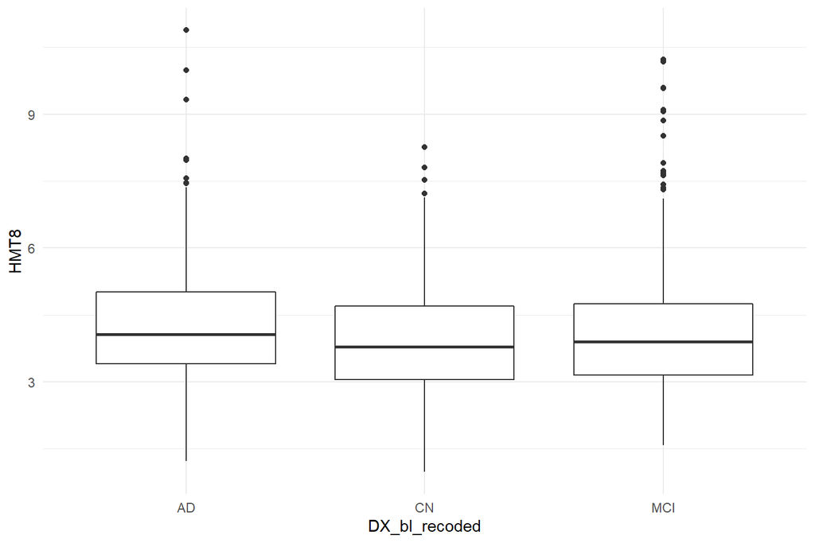

```r
ggplot(POR_data_ADNI1GO2) +
  theme_minimal() +
  geom_boxplot(aes(DX_bl_recoded, HMT8))
```

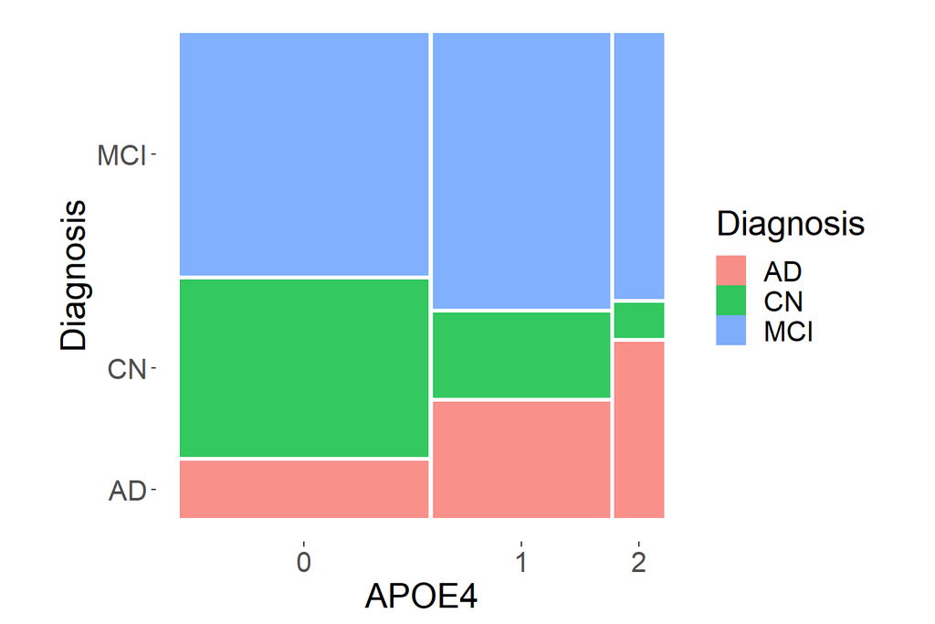

```r
library(ggmosaic)
POR_data_ADNI1GO2 %>%
  rename(Diagnosis = DX_bl_recoded) %>%
  ggplot() +
    geom_mosaic(aes(x = product(APOE4), fill=Diagnosis)) +
    theme_mosaic() +
    theme(text = element_text(size = 20))
```

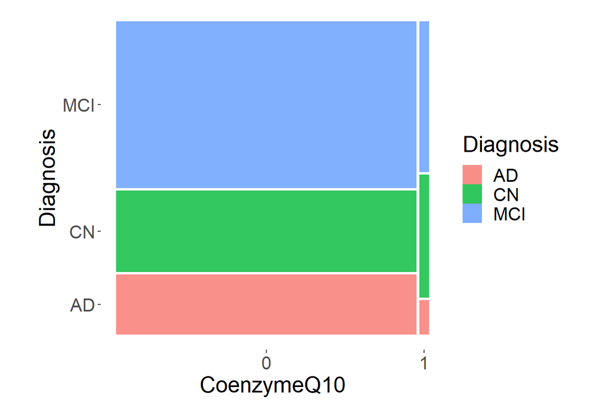

```r
POR_data_ADNI1GO2 %>%
  rename(Diagnosis = DX_bl_recoded) %>%
  rename(CoenzymeQ10 = "CMMED_coenzyme q10") %>%
  ggplot() +
    geom_mosaic(aes(x = product(CoenzymeQ10), fill=Diagnosis)) +
    theme_mosaic() +
    theme(text = element_text(size = 20))
```

## Age by Diagnosis ADNI1GO2

```r
POR_data_ADNI1GO2 %>%
  group_by(DX_bl_recoded) %>%
  summarise(avg = mean(AGE))
```

```
## # A tibble: 3 x 2
##   DX_bl_recoded   avg
##   <chr>         <dbl>
## 1 AD             75.2
## 2 CN             74.7
## 3 MCI            73.1
```

# Conclusions

Results are interesting. Will require some processing and thought.

# Considerations for Future Analyses

- Should redo the univariate tests while controlling for the affect of age.
- Could refine methodology of variable extraction from text. Instead of doing text cleaning, reduce number of false negatives by word extraction.